# Lab1

## Deng Wen 17307130171

### Problem 1.

```python
def sum_all_numbers(l):
    """
    sum all numbers in a list
    :param l: input list
    :return: a number
    """
    if type(l) != list:
        raise TypeError("The input parameter type must be a list!")
    result = 0
    for ele in l:
        if type(ele) in [int, float]:  # only calculate numbers.
            result += ele
    return result


# examples:
l1 = ["xxx", 1, 2, 3, 4]  # Case1: "xxx" is string, so ignored, 1+2+3+4=10
l2 = [345, 2.2, "what", False]  # Case2: "what" is string, False is bool, so 345+2.2=347.2
l3 = "hello"  # "hello" is not a list, and will raise an error
print(sum_all_numbers(l1))
print(sum_all_numbers(l2))
try:
    print(sum_all_numbers(l3))
except TypeError as e:
    print(e)
```

```
10
347.2
The input parameter type must be a list!
```

- Case1: "xxx" is string, so ignored, so we have 1+2+3+4=10
- Case2: "what" is string, False is bool, so 345+2.2=347.2
- Case3: "hello" is not a list, and will raise an error.

### Problem 2.

```python
def list2unique(l):
    """
    Given a list, return its all unique elements
    :param l: input list
    :return: list with unique elements
    """
    if type(l) != list:
        raise TypeError("The input parameter type must be a list!")
    result = []
    for ele in l:
        if ele not in result:  # check if the element is unique
            result.append(ele)
    return result


# examples:
l1 = [1, 2, 2, 2, 1, 5, 6, 7, 8, 5]  # Case1: Normal case, return [1, 2, 5, 6, 7, 8]
l2 = ["xxx", "xxx", "what", "1", 1, 2, 3, 2, 3, True, True]
l3 = ["xxx", "xxx", "what", "1", 2, 3, 2, 3, True, True]  # Case2 & 3: In python3,
                                                          # 1 is considered equivalent to bool variable True.
                                                          # So it will only keep 1 remained in Case2.
l4 = "1,2,3,4"  # Case4: not a list and will raise an error.
print(list2unique(l1))
print(list2unique(l2))
print(list2unique(l3))
try:
    print(list2unique(l4))
except TypeError as e:
    print(e)
```

```
[1, 2, 5, 6, 7, 8]
['xxx', 'what', '1', 1, 2, 3]
['xxx', 'what', '1', 2, 3, True]
The input parameter type must be a list!
```

- Case1: Normal case, return [1, 2, 5, 6, 7, 8]
- Case2 & 3: In python3,1 is considered equivalent to bool variable True.So it will only keep 1 remained in Case2.
- Case3: not a list and will raise an error.

### Problem 3.

```python
def is_palindrom(s):
    """
    judge a string s is palindrom or not
    :param s: input string, can be word, phrase or sequence
    :return: a bool factor
    """
    if type(s) != str:
        raise TypeError("The input parameter type must be a string!")
    s = s.lower()  # In this problem, the algorithm is not case sensitive.
    i = 0
    j = len(s)-1
    while i < j:
        if s[i] == " ":  # overlook whitespace
            i += 1
            continue
        if s[j] == " ":  # overlook whitespace
            j -= 1
            continue
        if s[i] != s[j]:  # if the two letters match
            return False
        i += 1
        j -= 1
    return True


# examples:
s1 = "nurses run"  # Case1: It's an example in the given lab1.pdf.
s2 = "abd d d d b a"  # Case2: After removing whitespace, "abddddba" is a palindrom
s3 = "f h f h f h"  # Case3: "h f h f h f" not correspont with "f h f h f h".
print(is_palindrom(s1))
print(is_palindrom(s2))
print(is_palindrom(s3))
```

```
True
True
False
```

In this problem, we have assumed that the letter case doesn't matter

- Case1: It's an example in the given lab1.pdf.
- Case2: After removing whitespace, "abddddba" is a palindrom
- Case3: "h f h f h f" not correspont with "f h f h f h".

### Problem 4

```python
import numpy as np


def complex_split(x):
    """
    ﬁnd the real and imaginary parts of an array of complex numbers
    :param x: Input array x, contains some complex numbers
    :return:array of real and imaginary parts of every complex numbers
    """
    result = []
    for ele in x:
        result.append(np.array([ele.real, ele.imag]))  # split the complex number into two parts and compose them as array
                                                       # before adding to the result
    return np.array(result)  # convert result to array form


# Examples:
x1 = np.array([1.00000000+0.j, 0.70710678+0.70710678j])
x2 = np.array([33-2j, -2j, 0, 1e-5+2j])
x3 = np.array([1.23+3.21j, 0.123456-0.654321j, 5, -3j])
print(complex_split(x1))
print(complex_split(x2))
print(complex_split(x3))
```

```
[[1.         0.        ]
 [0.70710678 0.70710678]]
[[ 3.3e+01 -2.0e+00]
 [-0.0e+00 -2.0e+00]
 [ 0.0e+00  0.0e+00]
 [ 1.0e-05  2.0e+00]]
[[ 1.23      3.21    ]
 [ 0.123456 -0.654321]
 [ 5.        0.      ]
 [-0.       -3.      ]]
```

- Case1:Normal Case from lab1.pdf
- Case2:We can see if one of the data is using scientific representation, all the result will be the same.
- Case3:In occurs -0 in the result, but it is correct that -0 is also 0.

### Problem 5

```python
def binary_add(x, y):
    """
    to add two binary numbers
    :param x: a string like "1001"
    :param y: a string like "1"
    :return: a string like "1010"
    """
    if x.count("1") + x.count("0") != len(x) or y.count("1") + y.count("0") != len(y):
        raise ValueError("The input string must only contain 1 and 0")
    result = ""
    i, j = len(x)-1, len(y)-1
    car = 0
    while i >= 0 and j >= 0:  # This is for the lower bits of two numbers
        tmp = int(x[i]) + int(y[j]) + car
        cur = tmp % 2  # number in the current position
        car = tmp // 2  # the number carry into the next position
        result = str(int(cur)) + result  # convert to string
        i -= 1  # update x
        j -= 1  # update y
    while i >= 0:  # This is x > y, only need to consider x
        tmp = int(x[i]) + car
        cur = tmp % 2
        car = tmp // 2
        if car + cur >0 or j != 0:
            result = str(int(cur)) + result
        i -= 1
    while j >= 0:  # This is x < y, only need to consider y
        tmp = int(y[j]) + car
        cur = tmp % 2
        car = tmp // 2
        if car + cur > 0 or j != 0:
            result = str(int(cur)) + result
        j -= 1
    if car:
        result = str(int(car)) + result
    return result


# Examples:
x1, y1 = "11", "1"
x2, y2 = "1111", "1111111"
x3, y3 = "11111", "0"
x4, y4 = "55", "10"
print(binary_add(x1, y1))
print(binary_add(x2, y2))
print(binary_add(x3, y3))
try:
    print(binary_add(x4, y4))
except ValueError as e:
    print(e)
```

```
100
10001110
11111
The input string must only contain 1 and 0
```

- Case1: Given case from lab1.pdf.
- Case2: A normal case which contains carry many times.
- Case3: A normal case which has no carry.
- Case4: A wrong case which will raise an error because the input is not 1 and 0.

### Problem 6

```python
class ListNode:
    def __init__(self, x):
        self.val = x
        self.next = None


def list_node_add(x, y):
    """
     Add the two numbers represented by listNode and return it as a linked list.
    :param x: a listNode storing a number
    :param y: a listNode storing a number
    :return:a listNode storing number = x + y
    """
    result = None
    p = None
    car = 0
    while x and y:  # This is for the lower part of x and y.
        tmp = x.val + y.val + car
        cur = tmp % 10  # number of current position
        if result is None:  # initialize a ListNode
            result = ListNode(cur)
            p = result
        else:
            p.next = ListNode(cur)  # link it to the generated ListNode
            p = p.next
        car = tmp // 10   # The number carrying into the next position
        x = x.next  # update x
        y = y.next  # update y
    while x:  # this is the length of x bigger than the length of y
        tmp = x.val + car
        cur = tmp % 10
        p.next = ListNode(cur)
        p = p.next
        car = tmp // 10
        x = x.next
    while y:  # this is the length of y bigger than the length of x
        tmp = y.val + car
        cur = tmp % 10
        p.next = ListNode(cur)
        p = p.next
        car = tmp // 10
        y = y.next
    if car:
        p.next = ListNode(car)
    return result


# Examples:
# ------------Data generated----------

x1, y1 = ListNode(2), ListNode(5)
x1.next,y1.next = ListNode(4), ListNode(6)
x1.next.next, y1.next.next = ListNode(3), ListNode(4)
x2, y2 = ListNode(4), ListNode(5)
y2.next = ListNode(9)
y2.next.next = ListNode(4)
x3, y3 = ListNode(9), ListNode(8)
x3.next,y3.next = ListNode(9), ListNode(8)
x3.next.next, y3.next.next = ListNode(9), ListNode(8)

# ------------Code testing--------------
print("\n" + "---Example1---")
result1 = list_node_add(x1, y1)
print(result1.val, end="")
while result1.next:
    result1 =  result1.next
    print("->", end="")
    print(result1.val, end="")
result2 = list_node_add(x2, y2)
print("\n" + "---Example2---")
print(result2.val, end="")
while result2.next:
    result2 =  result2.next
    print("->", end="")
    print(result2.val, end="")
print("\n" + "---Example3---")
result3 = list_node_add(x3, y3)
print(result3.val, end="")
while result3.next:
    result3 =  result3.next
    print("->", end="")
    print(result3.val, end="")
```

```
---Example1---
7->0->8
---Example2---
9->9->4
---Example3---
7->8->8->1
```

- Case1: Given case from lab1.pdf
- Case2: A case has no carry in the computing process.
- Case3: A case has many carrys in the computing process.

### Problem 7

```python
def bubble_sort(nums):
    """
    sort the list of numbers using bubble sort.
    :param nums: the input list of numbers
    :return: list of numbers already sorted
    """
    for i in range(len(nums) - 1):  # control the iterate times
        for j in range(len(nums) - i - 1):  # only consider the first n-i numbers for the last i are already sorted
            if nums[j] > nums[j+1]:  # disorder
                nums[j], nums[j+1] = nums[j+1], nums[j]  # switch
    return nums


# Examples
nums1 = [8, 4, 0, 22, 180, 3]
nums2 = [999999, -125, 100, -98, 13579]
nums3 = [1e-5, 10000, 3.3, -9, -88, 250]
print(bubble_sort(nums1))
print(bubble_sort(nums2))
print(bubble_sort(nums3))
```

```
[0, 3, 4, 8, 22, 180]
[-125, -98, 100, 13579, 999999]
[-88, -9, 1e-05, 3.3, 250, 10000]
```

- Case1: A normal case with only positive numbers.
- Case2: Case with both positive and negative numbers.
- Case3: Case with int and float numbers.

### Problem 8

```python
def merge_sort(nums):
    """
    sort the list of numbers using merge sort
    :param nums: the input list of numbers
    :return: list of numbers already sorted
    """
    if len(nums) <= 1:  # the terminal condition
        return nums
    pivot = int(len(nums)/2)  # the partition position
    left = merge_sort(nums[:pivot])  # divide
    right = merge_sort(nums[pivot:])
    return merge(left, right)  # conquer


def merge(left, right):
    """
    merge two sorted list together
    :param left: the left list
    :param right:  the right list
    :return: a sorted list
    """
    result = []
    i, j = 0, 0
    while i < len(left) and j < len(right):  # iteration condition
        if left[i] <= right[j]:  # add the smaller into the list
            result.append(left[i])
            i += 1
        else:
            result.append(right[j])
            j += 1
    result += list(left[i:])  # the remain numbers
    result += list(right[j:])
    return result


# Examples
nums1 = [8, 4, 0, 22, 180, 3]
nums2 = [999999, -125, 100, -98, 13579]
nums3 = [1e-5, 10000, 3.3, -9, -88, 250]
print(merge_sort(nums1))
print(merge_sort(nums2))
print(merge_sort(nums3))
```

```
[0, 3, 4, 8, 22, 180]
[-125, -98, 100, 13579, 999999]
[-88, -9, 1e-05, 3.3, 250, 10000]
```

The following case are the same with the bubble sort case.

- Case1: A normal case with only positive numbers.
- Case2: Case with both positive and negative numbers.
- Case3: Case with int and float numbers.

### Problem 9

```python
def quick_sort(nums):
    """
    sort the list of numbers using quick sort
    :param nums: the input list of numbers
    :return: list of numbers already sorted
    """
    if len(nums) <= 1:  # the terminal condition
        return nums
    pivot = nums[int(len(nums)/2)]  # choose the middle number as the pivot
    left, right = [], []            # left, right part
    for i in range(len(nums)):
        if i == int(len(nums)/2):   # the pivot doesn't count
            continue
        elif nums[i] >= pivot:      # if x > pivot, belong to right
            right.append(nums[i])
        else:                       # x < pivot, belong to left
            left.append(nums[i])
    return quick_sort(left) + [pivot] + quick_sort(right)  # combine together


# Examples
nums1 = [8, 4, 0, 22, 180, 3]
nums2 = [999999, -125, 100, -98, 13579]
nums3 = [1e-5, 10000, 3.3, -9, -88, 250]
print(quick_sort(nums1))
print(quick_sort(nums2))
print(quick_sort(nums3))
```

```
[0, 3, 4, 8, 22, 180]
[-125, -98, 100, 13579, 999999]
[-88, -9, 1e-05, 3.3, 250, 10000]
```

The following case are the same with the bubble sort case.

- Case1: A normal case with only positive numbers.
- Case2: Case with both positive and negative numbers.
- Case3: Case with int and float numbers.

### Problem 10

```python
def shell_sort(nums):
    """
    sort the list of numbers using shell's sort
    :param nums: the input list of numbers
    :return: list of numbers already sorted
    """
    gap = len(nums)//2                      # initialize gap
    while gap > 0:                          # terminal condition
        for i in range(gap, len(nums)):
            temp = nums[i]                  # keep record of current val
            j = i
            while j >= gap and nums[j-gap] > temp:  # disorder
                nums[j] = nums[j-gap]        # insert
                j -= gap                     # update j
            nums[j] = temp                   # switch
        gap = gap // 2                       # update gap
    return nums


# Examples
nums1 = [8, 4, 0, 22, 180, 3]
nums2 = [999999, -125, 100, -98, 13579]
nums3 = [1e-5, 10000, 3.3, -9, -88, 250]
print(shell_sort(nums1))
print(shell_sort(nums2))
print(shell_sort(nums3))
```

```
[0, 3, 4, 8, 22, 180]
[-125, -98, 100, 13579, 999999]
[-88, -9, 1e-05, 3.3, 250, 10000]
```

The following case are the same with the bubble sort case.

- Case1: A normal case with only positive numbers.
- Case2: Case with both positive and negative numbers.
- Case3: Case with int and float numbers.

### Problem 11

```
Epoch[10/50], loss: 0.473147
Epoch[20/50], loss: 0.455796
Epoch[30/50], loss: 0.439846
Epoch[40/50], loss: 0.425183
Epoch[50/50], loss: 0.411705
```

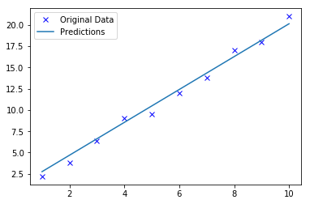

```python
import numpy as np
import torch
import torch.nn as nn
import matplotlib.pyplot as plt
from torch.autograd import Variable


class LinearRegressionModel(nn.Module):
    def __init__(self, in_size, out_size):
        super(LinearRegressionModel, self).__init__()
        self.linear = nn.Linear(in_size, out_size)

    def forward(self, x):
        out = self.linear(x)
        return out


# initialize hyper parameters, model,  loss function and optimizer
learning_rate = 0.01
epochs = 50
in_size = 1
out_size = 1
model = LinearRegressionModel(in_size, out_size)
criterion = nn.MSELoss()
optimizer = torch.optim.SGD(model.parameters(), lr=learning_rate)

# input data
x = np.array([1, 2, 3, 4, 5, 6, 7, 8, 9, 10], dtype=np.float32)
y = np.array([2.2, 3.8, 6.4, 9, 9.5, 12, 13.8, 17, 18, 21], dtype=np.float32)
x = x.reshape((10, 1))
y = y.reshape((10, 1))
# convert to torch.tensor
x_train = Variable(torch.from_numpy(x).float())  # Autograd
y_train = Variable(torch.from_numpy(y).float())

for epoch in range(epochs):

    optimizer.zero_grad()  # empty the gradients
    outputs = model(x_train)  # forward

    loss = criterion(outputs, y_train)  # compute the loss
    loss.backward()  # backward

    optimizer.step()  # update parameters

    if (epoch + 1) % 10 == 0:  # print loss
        print('Epoch[{}/{}], loss: {:.6f}'.format(epoch + 1, epochs, loss.item()))

# predict
model.eval()
pred = model(x_train)
pred = pred.detach().numpy()

# visualization
%matplotlib inline
plt.plot(x, y, "bx", label="Original Data")
plt.plot(x, pred, label="Predictions")
plt.legend()
plt.show()

# torch.save(model.state_dict()) # Save the model
```

- The test case is a one-dimensional case, and it's a completely manual.
- *The detail can be seen in the comments of the code.*

### Problem 12

```python
import numpy as np
import torch
import torch.nn as nn
from torch.autograd import Variable


class LogisticRegressionModel(nn.Module):
    def __init__(self, in_size, out_size):
        super(LogisticRegressionModel, self).__init__()
        self.linear = nn.Linear(in_size, out_size)
        self.sigmoid = nn.Sigmoid()

    def forward(self, x):
        out = self.sigmoid(self.linear(x))
        return out


# initialize hyper parameters, model,  loss function and optimizer
learning_rate = 0.01
epochs = 50
in_size = 2
out_size = 1
model = LogisticRegressionModel(in_size, out_size)
criterion = nn.BCELoss()
optimizer = torch.optim.SGD(model.parameters(), lr=learning_rate)

# input data
x = np.array([[1, 9], [2, 11], [5, 1], [8, 0], [4, 9.5], [6, 2.5],
              [2.2, 10.3], [7.5, 1.9], [9.2, 0.7], [0.88, 6.2]], dtype=np.float32)
y = np.array([0, 0, 1, 1, 0, 1, 0, 1, 1, 0], dtype=np.float32)

y = y.reshape((10, 1))
# autograd
x_train = Variable(torch.from_numpy(x).float())
y_train = Variable(torch.from_numpy(y).float())

for epoch in range(epochs):

    optimizer.zero_grad()  # empty the gradients
    outputs = model(x_train)  # forward

    loss = criterion(outputs, y_train)  # compute the loss
    loss.backward()  # backward

    optimizer.step()  # update parameters

    if (epoch + 1) % 10 == 0:
        print('Epoch[{}/{}], loss: {:.6f}'.format(epoch + 1, epochs, loss.item()))

model.eval()
pred = model(x_train)
pred = pred.detach().numpy()
print("Predict on train set")
print(pred)
print("---convert: if > 0.5: 1 else: 0---")
print(np.int64(pred > 0.5))
print("-----Test-----")
print("Input: (0.5, 9.2):", sep="")
print(model(torch.from_numpy(np.array([[0.5, 9.2]])).float()).detach().numpy()[0])
print("Input: (6.7, 1.2):", sep="")
print(model(torch.from_numpy(np.array([[6.7, 1.2]])).float()).detach().numpy()[0])

# torch.save(model.state_dict()) # Save the model
```

```
Epoch[10/50], loss: 0.199799
Epoch[20/50], loss: 0.134338
Epoch[30/50], loss: 0.104107
Epoch[40/50], loss: 0.087120
Epoch[50/50], loss: 0.076178
Predict on train set
[[0.01811212]
 [0.01289984]
 [0.81451297]
 [0.9690216 ]
 [0.06465825]
 [0.7939732 ]
 [0.01916211]
 [0.91478884]
 [0.97718686]
 [0.05440523]]
---convert: if > 0.5: 1 else: 0---
[[0]
 [0]
 [1]
 [1]
 [0]
 [1]
 [0]
 [1]
 [1]
 [0]]
-----Test-----
Input: (0.5, 9.2):
[0.01294008]
Input: (6.7, 1.2):
[0.9058438]
```

- This case has two-dimensional input and one-dimensional output. This dataset is also manual. It was designed that the numner in the first dimension is larger and the number in the second dimension is lower will lead to output approach to 1.
- We can see that if we convert the output of the model to let it be 1 if it is bigger than 0.5, else 0. The result will meet our expectations.

### Problem 13

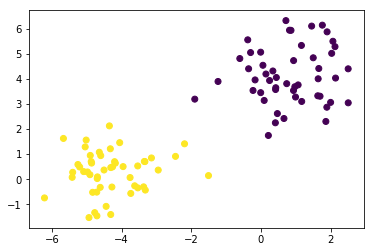

```
Epoch[50/500], loss: 0.050285
Epoch[100/500], loss: 0.033269
Epoch[150/500], loss: 0.025942
Epoch[200/500], loss: 0.022716
Epoch[250/500], loss: 0.020166
Epoch[300/500], loss: 0.018962
Epoch[350/500], loss: 0.017802
Epoch[400/500], loss: 0.016643
Epoch[450/500], loss: 0.015615
Epoch[500/500], loss: 0.014650
```

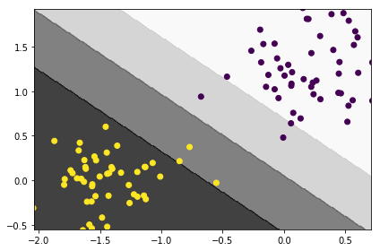

```python
import numpy as np
import torch
import torch.nn as nn
from torch.autograd import Variable
import matplotlib.pyplot as plt
from sklearn.datasets.samples_generator import make_blobs
%matplotlib inline


class SupportVectorMachine(nn.Module):
    def __init__(self, in_size):
        super(SupportVectorMachine, self).__init__()
        self.linear = nn.Linear(in_size, 1)

    def forward(self, x):
        out = self.linear(x)
        return out


def hing_loss(outputs, labels):
    loss = torch.clamp(1-outputs*labels, min=0)
    loss = torch.mean(loss)
    return loss


# initialize hyper parameters, model,  loss function and optimizer
learning_rate = 0.05
epochs = 500
in_size = 2
out_size = 1
model = SupportVectorMachine(in_size)
optimizer = torch.optim.SGD(model.parameters(), lr=learning_rate)

# input data
x, y = make_blobs(n_samples=100, centers=2, random_state=3, cluster_std=[1, 1])  # use sklearn to generate data sets
# Plot the data
plt.scatter(x[:, 0], x[:, 1], c=y)
plt.show()
# feature scaling
x = (x - x.mean())/x.std()
# plot the data after scaling
# plt.scatter(x[:, 0], x[:, 1], c=y)
# plt.show()
# replace 0 with -1
y[y == 0] = -1
y = np.reshape(y, (100, 1))


# autograd
x_train = Variable(torch.from_numpy(x).float())
y_train = Variable(torch.from_numpy(y).float())

for epoch in range(epochs):

    optimizer.zero_grad()  # empty the gradients
    outputs = model(x_train)  # forward

    loss = hing_loss(outputs, y_train)  # compute the loss
    loss.backward()  # backward

    optimizer.step()  # update parameters

    if (epoch + 1) % 50 == 0:
        print('Epoch[{}/{}], loss: {:.6f}'.format(epoch + 1, epochs, loss.item()))

# Visualize
W = model.linear.weight[0].data.cpu().numpy()
b = model.linear.bias[0].data.cpu().numpy()

delta = 0.01  # sep of coordinates
# coordinates
_x = np.arange(x[:, 0].min(), x[:, 0].max(), delta)
_y = np.arange(x[:, 1].min(), x[:, 1].max(), delta)
_x, _y = np.meshgrid(_x, _y)
coordinates = list(map(np.ravel, [_x, _y]))

# draw the different areas
z = (W.dot(coordinates) + b).reshape(_x.shape)
z[np.where(z > 1.)] = 4
z[np.where((z > 0.) & (z <= 1.))] = 3
z[np.where((z > -1.) & (z <= 0.))] = 2
z[np.where(z <= -1.)] = 1

# draw the picture
plt.xlim([x[:, 0].min() + delta, x[:, 0].max() - delta])
plt.ylim([x[:, 1].min() + delta, x[:, 1].max() - delta])
plt.contourf(_x, _y, z, alpha=0.8, cmap="Greys")
plt.scatter(x[:, 0], x[:, 1], c=np.squeeze(y))
plt.tight_layout()
plt.show()
```

- This case was generated by the function *make_blobs* in *sklearn*. And the data is linearly separable.
- In this model, raise the number of learning rate and the epochs does help in the convergence.
- I have done feature scaling in the pre-process of the data. The reason to do feature scaling is that, if we don't standardize the data magnitude, the result may easily be dominated by the feature with large magnitude. Because SVM is not affine transformation invariant.

### Problem 14

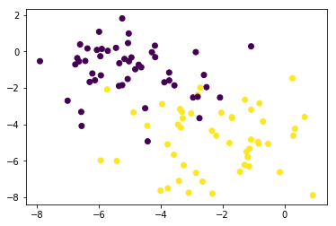

```
-------------------------Method I----------------------------------
Epoch[100/500], loss: 0.242689
Epoch[200/500], loss: 0.228971
Epoch[300/500], loss: 0.223891
Epoch[400/500], loss: 0.222177
Epoch[500/500], loss: 0.221494
```

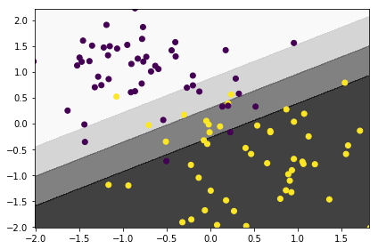

```
-------------------------Method II----------------------------------
Epoch[100/500], loss: 0.379402
Epoch[200/500], loss: 0.384368
Epoch[300/500], loss: 0.395356
Epoch[400/500], loss: 0.404669
Epoch[500/500], loss: 0.410450
```

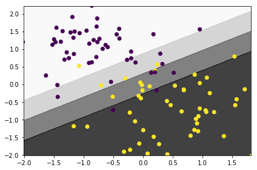

```python
import numpy as np
import torch
import torch.nn as nn
from torch.autograd import Variable
import matplotlib.pyplot as plt
from sklearn.datasets.samples_generator import make_blobs
%matplotlib inline


# two ways of compute hinge loss with  Frobenius norm penalty.

# Use function in torch
def hing_loss_LF1(outputs, labels, w, alpha=0.01):
    loss = torch.clamp(1 - outputs * labels, min=0)
    loss = torch.mean(loss)
    loss += alpha*torch.norm(w, p="fro")
    return loss


# self-defined compute
def hing_loss_LF2(outputs, labels, w, alpha=0.1):
    loss = torch.clamp(1 - outputs * labels, min=0)
    loss = torch.mean(loss)
    loss += alpha*np.sqrt((w**2).sum())
    return loss


# Repeat the process similar in problem 13
class SupportVectorMachine(nn.Module):
    def __init__(self, in_size):
        super(SupportVectorMachine, self).__init__()
        self.linear = nn.Linear(in_size, 1)

    def forward(self, x):
        out = self.linear(x)
        return out


# input data -- Note this data is not linearly seperated.
x, y = make_blobs(n_samples=100, centers=2, random_state=33, cluster_std=[1.4, 1.6])  # use sklearn to generate data sets
# Plot the data
plt.scatter(x[:, 0], x[:, 1], c=y)
plt.show()
# feature scaling
x = (x - x.mean())/x.std()
# draw picture after scaling
# plt.scatter(x[:, 0], x[:, 1], c=y)
# plt.show()
# replace 0 with -1
y[y == 0] = -1
y = np.reshape(y, (100, 1))

# -------------------------Method I----------------------------------
print("-------------------------Method I----------------------------------")
# initialize hyper parameters, model,  loss function and optimizer
learning_rate = 0.06
epochs = 500
in_size = 2
out_size = 1
model = SupportVectorMachine(in_size)
optimizer = torch.optim.SGD(model.parameters(), lr=learning_rate)

# autograd
x_train = Variable(torch.from_numpy(x).float())
y_train = Variable(torch.from_numpy(y).float())

for epoch in range(epochs):

    optimizer.zero_grad()  # empty the gradients
    outputs = model(x_train)  # forward

    loss = hing_loss_LF1(outputs, y_train, model.linear.weight[0].data)  # compute the loss
    loss.backward()  # backward

    optimizer.step()  # update parameters

    if (epoch + 1) % 100 == 0:
        print('Epoch[{}/{}], loss: {:.6f}'.format(epoch + 1, epochs, loss.item()))

# Visualize
W = model.linear.weight[0].data.cpu().numpy()
b = model.linear.bias[0].data.cpu().numpy()

delta = 0.01  # sep of coordinates
# coordinates
_x = np.arange(x[:, 0].min(), x[:, 0].max(), delta)
_y = np.arange(x[:, 1].min(), x[:, 1].max(), delta)
_x, _y = np.meshgrid(_x, _y)
coordinates = list(map(np.ravel, [_x, _y]))

# draw the different areas
z = (W.dot(coordinates) + b).reshape(_x.shape)
z[np.where(z > 1.)] = 4
z[np.where((z > 0.) & (z <= 1.))] = 3
z[np.where((z > -1.) & (z <= 0.))] = 2
z[np.where(z <= -1.)] = 1

# draw the picture
plt.xlim([x[:, 0].min() + delta, x[:, 0].max() - delta])
plt.ylim([x[:, 1].min() + delta, x[:, 1].max() - delta])
plt.contourf(_x, _y, z, alpha=0.8, cmap="Greys")
plt.scatter(x[:, 0], x[:, 1], c=np.squeeze(y))
plt.tight_layout()
plt.show()

# -------------------------Method II----------------------------------
print("-------------------------Method II----------------------------------")
# initialize hyper parameters, model,  loss function and optimizer
learning_rate = 0.06
epochs = 500
in_size = 2
out_size = 1
model = SupportVectorMachine(in_size)
optimizer = torch.optim.SGD(model.parameters(), lr=learning_rate)

# autograd
x_train = Variable(torch.from_numpy(x).float())
y_train = Variable(torch.from_numpy(y).float())

for epoch in range(epochs):

    optimizer.zero_grad()  # empty the gradients
    outputs = model(x_train)  # forward

    loss = hing_loss_LF2(outputs, y_train, model.linear.weight[0].data)  # compute the loss
    loss.backward()  # backward

    optimizer.step()  # update parameters

    if (epoch + 1) % 100 == 0:
        print('Epoch[{}/{}], loss: {:.6f}'.format(epoch + 1, epochs, loss.item()))

# Visualize
W = model.linear.weight[0].data.cpu().numpy()
b = model.linear.bias[0].data.cpu().numpy()

delta = 0.01  # sep of coordinates
# coordinates
_x = np.arange(x[:, 0].min(), x[:, 0].max(), delta)
_y = np.arange(x[:, 1].min(), x[:, 1].max(), delta)
_x, _y = np.meshgrid(_x, _y)
coordinates = list(map(np.ravel, [_x, _y]))

# draw the different areas
z = (W.dot(coordinates) + b).reshape(_x.shape)
z[np.where(z > 1.)] = 4
z[np.where((z > 0.) & (z <= 1.))] = 3
z[np.where((z > -1.) & (z <= 0.))] = 2
z[np.where(z <= -1.)] = 1

# draw the picture
plt.xlim([x[:, 0].min() + delta, x[:, 0].max() - delta])
plt.ylim([x[:, 1].min() + delta, x[:, 1].max() - delta])
plt.contourf(_x, _y, z, alpha=0.8, cmap="Greys")
plt.scatter(x[:, 0], x[:, 1], c=np.squeeze(y))
plt.tight_layout()
plt.show()
```

- function hing_loss_LF1 has used the torch.norm function built inside torch to compute for forbenius norm
- function hing_loss_LF2 's method of computing forbenius norm is designed by myself.
- I have run a new data set generated similaryl in problem 13 to do binary classifier in SVM.
- However, the data is not linearly seperated.
- The two methods have got nearly the same result which means they are equivalent.
- The detailed information can be seen in the code and comments.

### Problem 15

```
------------Linear Regression----------------
Coefficient: [2.0515153]
Intercept: -0.013335228
```

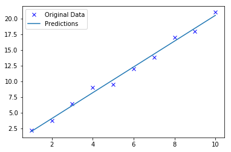

```
------------Logistic Regression----------------
Coefficient: [[ 0.67333301 -0.61211845]]
Intercept: [0.04885787]
Predict on train set
[0. 0. 1. 1. 0. 1. 0. 1. 1. 0.]
-----Test-----
Input: (0.5, 9.2):
[0.]
Input: (6.7, 1.2):
[1.]
-------------Support Vector Machine---------------
```

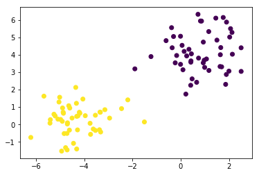

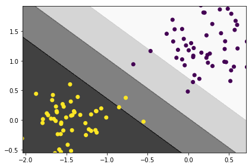

```python
import numpy as np
import matplotlib.pyplot as plt
from sklearn.datasets.samples_generator import make_blobs
from sklearn import linear_model
from sklearn.svm import SVC
%matplotlib inline


# ------------Linear Regression----------------
print("------------Linear Regression----------------")
# generate data
x = np.array([1, 2, 3, 4, 5, 6, 7, 8, 9, 10], dtype=np.float32)
x = x.reshape(-1, 1)
y = np.array([2.2, 3.8, 6.4, 9, 9.5, 12, 13.8, 17, 18, 21], dtype=np.float32)

# Model import
lm = linear_model.LinearRegression()

# Fit a linear regression
lm.fit(x, y)

# learned parameters
print("Coefficient:", lm.coef_)
print("Intercept:", lm.intercept_)

# visualize
pred = lm.predict(x)

plt.plot(x, y, "bx", label="Original Data")
plt.plot(x, pred, label="Predictions")
plt.legend()
plt.show()

# -------------Logistic Regression----------------
print("------------Logistic Regression----------------")
# generate data
x = np.array([[1, 9], [2, 11], [5, 1], [8, 0], [4, 9.5], [6, 2.5],
              [2.2, 10.3], [7.5, 1.9], [9.2, 0.7], [0.88, 6.2]], dtype=np.float32)
y = np.array([0, 0, 1, 1, 0, 1, 0, 1, 1, 0], dtype=np.float32)

# model import
lm = linear_model.LogisticRegression(solver="liblinear")

# fit a regression
lm.fit(x, y)

# learned parameters
print("Coefficient:", lm.coef_)
print("Intercept:", lm.intercept_)

# predict on train set
pred = lm.predict(x)
print("Predict on train set")
print(pred)

# predict on new data
print("-----Test-----")
print("Input: (0.5, 9.2):", sep="")
print(lm.predict([[0.5, 9.2]]))
print("Input: (6.7, 1.2):", sep="")
print(lm.predict([[6.7, 1.2]]))

# -------------Support Vector Machine---------------
print("-------------Support Vector Machine---------------")
# generate data
x, y = make_blobs(n_samples=100, centers=2, random_state=3, cluster_std=[1, 1])  # use sklearn to generate data sets
# Plot the data
plt.scatter(x[:, 0], x[:, 1], c=y)
plt.show()
# feature scaling
x = (x - x.mean())/x.std()
# replace 0 with -1
y[y == 0] = -1

# model import
model = SVC(kernel="linear")

# fit
model.fit(x, y)

# Visualize
delta = 0.01  # sep of coordinates
# coordinates
_x = np.arange(x[:, 0].min(), x[:, 0].max(), delta)
_y = np.arange(x[:, 1].min(), x[:, 1].max(), delta)
_x, _y = np.meshgrid(_x, _y)
coordinates = np.array(list(map(np.ravel, [_x, _y])))
coordinates = coordinates.transpose()

# draw the different areas
z = model.decision_function(coordinates)
z[np.where(z > 1.)] = 4
z[np.where((z > 0.) & (z <= 1.))] = 3
z[np.where((z > -1.) & (z <= 0.))] = 2
z[np.where(z <= -1.)] = 1
z = z.reshape(_x.shape)

# draw the picture
plt.xlim([x[:, 0].min() + delta, x[:, 0].max() - delta])
plt.ylim([x[:, 1].min() + delta, x[:, 1].max() - delta])
plt.contourf(_x, _y, z, alpha=0.8, cmap="Greys")
plt.scatter(x[:, 0], x[:, 1], c=np.squeeze(y))
plt.tight_layout()
plt.show()
```

- I have implemented three cases in Linear Regression, Logistic Regression, Support Vector Machine resepectively by using the function built in toolkit *scikit-learn*.
- After checking the result, I have got almost the same result compared with former methods which used *pytorch* toolkit.
- The detailed information can be seen in the code and comments.

### Problem 16

1. First, go to the website to download the [The CIFAR-10 dataset](http://www.cs.toronto.edu/~kriz/cifar.html) instead of download by torchvision because it is indeed very slow, over 85 hours. Even though, it is also a liitle slow to download from the website which may take a few hours.
2. Then, I will learn how to use it and visualize some of its images.

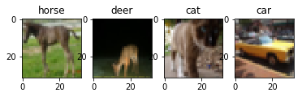

```python
import pickle
import matplotlib.pyplot as plt
import numpy as np
import os
%matplotlib inline


# load single batch
def unpickle(file):
    with open(file, 'rb') as fo:
        dict = pickle.load(fo, encoding='bytes')
    return dict


# load whole data
def load_cifar():
    """
    load all train and test data in cifar10
    :return: train,  test
    """
    labels = []
    data = []

    for b in range(1, 6):
        f = os.path.join('./cifar-10-batches-py/data_batch_%d' % (b,))
        d = unpickle(f)
        labels.append(d[b'labels'])
        data.append(d[b'data'].reshape(10000, 3, 32, 32).transpose(0, 2, 3, 1).astype("int"))  # convert the array to picture data
    train_labels = np.concatenate(labels)  # concatenate all train labels together
    train_data = np.concatenate(data)  #concatenate all train data together
    d = unpickle('./cifar-10-batches-py/test_batch')
    labels = d[b'labels']
    data = d[b'data'].reshape(10000, 3, 32, 32).transpose(0, 2, 3, 1).astype("int")
    return train_data, train_labels, data, labels


# all class names corresponding to the labels
classes = ('plane', 'car', 'bird', 'cat',
           'deer', 'dog', 'frog', 'horse', 'ship', 'truck')
# load data
train_data, train_labels, test_data, test_labels = load_cifar()
# visualize some images
# randomly choose four images
choices = np.random.choice(50000, 4)

for i in range(4):
    choice = choices[i]
    plt.subplot(1, 4, i+1)
    plt.imshow(train_data[choice])  # plot the picture
    plt.title(classes[train_labels[choice]])  # visualize the labels
plt.show()
```

- *The method I used to load the dataset is from the official website documention.*

### Problem 17

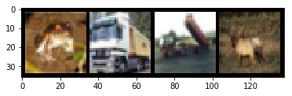

```
 frog truck truck  deer
```

```python
import numpy as np
import torch
import torch.nn as nn
from torch.utils.data import Dataset, DataLoader
import torchvision
import pickle
import os
import matplotlib.pyplot as plt
%matplotlib inline


# load single batch
def unpickle(file):
    with open(file, 'rb') as fo:
        dict = pickle.load(fo, encoding='bytes')
    return dict

# all labels
classes = ('plane', 'car', 'bird', 'cat',
           'deer', 'dog', 'frog', 'horse', 'ship', 'truck')


class DatasetCIFAR10(Dataset):
    def __init__(self, root='./cifar-10-batches-py/', train=True, transform=None, target_transform=None):
        self.labels = []
        self.data = []
        self.transform = transform
        self.target_transform = target_transform

        # the way of loading data is similar to the function defined in problem 16， but doesn;t convert to HWC form, keep CHW form.
        if train:  # to decide which dataset to load: train set or test set
            for b in range(1, 6):
                f = os.path.join(root, 'data_batch_%d' % (b,))
                d = unpickle(f)
                self.labels.append(d[b'labels'])
                self.data.append(d[b'data'].reshape(10000, 3, 32, 32).astype("int"))
            self.labels = np.concatenate(self.labels)
            self.data = np.concatenate(self.data)
        else:
            d = unpickle(root + 'test_batch')
            self.labels = d[b'labels']
            self.data = d[b'data'].reshape(10000, 3, 32, 32).astype("int")

    def __getitem__(self, index):
        img, label = self.data[index], self.labels[index]

        # to support transform operation
        if self.transform:
            img = self.transform(img)

        if self.target_transform:
            label = self.target_transform(label)

        return img, label

    def __len__(self):
        return len(self.data)


train_loader = DataLoader(DatasetCIFAR10(), 4, shuffle=False)

# -------the following code was refered to TA's tutorial----------
def imshow(img):
    npimg = img.numpy()
    plt.imshow(np.transpose(npimg, (1, 2, 0)))  # convert HWC form to visualize
    plt.show()


# get some random training images
dataiter = iter(train_loader)
images, labels = dataiter.next()

# show images
imshow(torchvision.utils.make_grid(images))
# print labels
print(' '.join('%5s' % classes[labels[j]] for j in range(4)))
```

- In this problem, I am supposed to implement a pytorch Dataset class for the CIFAR10 dataset.
- The key point to finish this job is to over the Dataset class by defining the *self.__len__* and *self.__getitem__* fucntion. So that it can be transfered into a Pytorch Dataloader.
- The detailed information can be seen in the code and comments.

### Problem 18

*torchvision.transiforms* are common image transformations. They can be chained together using *Compose*. Additionally, there is the *torchvision.transforms.functional* module. Functional transforms give fine-grained control over the transformations. This is useful if you have to build a more complex transformation pipeline.(*From official docs.*)

- The following are some examples of using *torchvision.transforms* to transform images.

```
(500, 500)
(300, 300)
```

[figure not shown]

[figure not shown]

[figure not shown]

[figure not shown]

```python
from torchvision import transforms
from PIL import Image
import matplotlib.pyplot as plt
%matplotlib inline


### class torchvision.transforms.CenterCrop(size)
"""
Crops the given PIL Image at the center.
size (sequence or python:int) – Desired output size of the crop.
If size is an int instead of sequence like (h, w), a square crop (size, size) is made.
"""
# --------Case-------------
crop = transforms.CenterCrop(300)
img = Image.open('test.jpg')

plt.subplot(121)
plt.imshow(img)
print(img.size)
croped_img = crop(img)
plt.subplot(122)
plt.imshow(croped_img)
print(croped_img.size)
plt.show()

### class torchvision.transforms.ColorJitter(brightness=0, contrast=0, saturation=0, hue=0)
"""
Randomly change the brightness, contrast and saturation of an image.
"""
# --------Case-------------
transform = transforms.ColorJitter((0, 0.6))

plt.subplot(121)
plt.imshow(img)
tran_img = transform(img)
plt.subplot(122)
plt.imshow(tran_img)
plt.show()

### class torchvision.transforms.RandomRotation(degrees, resample=False, expand=False, center=None, fill=0)
"""
Rotate the image by angle.
"""
# --------Case-------------
transform = transforms.RandomRotation((90, 90))

plt.subplot(121)
plt.imshow(img)
tran_img = transform(img)
plt.subplot(122)
plt.imshow(tran_img)
plt.show()

### class torchvision.transforms.Pad(padding, fill=0, padding_mode='constant')
"""
Pad the given PIL Image on all sides with the given “pad” value.
"""
# --------Case-------------
transform = transforms.Pad(50)

img = Image.open('test.jpg')

plt.subplot(121)
plt.imshow(img)
tran_img = transform(img)
plt.subplot(122)
plt.imshow(tran_img)
plt.show()
```

- There are also many other transform functions, and I will not give a specific example. Just keep their funcions record. These functions and their instructions can all be found in the [official website.](https://pytorch.org/docs/stable/torchvision/transforms.html)
1. **torchvision.transforms.Resize(size, interpolation=2)**: to resize images.
2. **torchvision.transforms.Normalize(mean, std)**: to normalize images.
3. **torchvision.transforms.ToPILImage(mode=None)**: to convert np.array into PIL.Image
4. **torchvision.transforms.ToTensor**: to convert images into torch.tensor
5. **torchvision.transforms.RandomCrop(size, padding=0, pad_if_needed=False)**: randomly crop images based on given size
6. **torchvision.transforms.RandomResizedCrop(size, scale=(0.08, 1.0), ratio=(0.75, 1.33), interpolation=2)**: crop images randomly based on the given scale and width-length ration, then resize images based on given size.
7. **torchvision.transforms.FiveCrop(size)**: Crop images from up, down, left, right and center. Will get 5 images, in 4D tensor form.
8. **torchvision.transforms.TenCrop(size, vertical_flip=False)**: Crop images from up, down, left, right and center, and filp them vertically or horizontally. Will get 10 images, in 4D tensor form.
9. **torchvision.transforms.RandomHorizontalFlip(p=0.5)**: Randomly filp images horizontally based on given probability.
10. **torchvision.transforms.RandomVerticalFlip(p=0.5)**: Randomly filp images vertically based on given probability.
11. **torchvision.transforms.Grayscale(num_output_channels=1)**: convert images into grey images.
12. **torchvision.transforms.RandomGrayscale(p=0.1)**: convert images into grey images based on given probability.
13. **torchvision.transforms.LinearTransformation(transformation_matrix)**: Do linear transformation to images.
14. **torchvision.transforms.RandomAffine(degrees, translate=None, scale=None, shear=None, resample=False, fillcolor=0)**: Do randomly affine transformation to images.

Above are the most functions built in the *torchvision.transforms*.

- And it also provides Generic Transforms, which canbe defined by users:  
  **torchvision.transforms.Lambda(lambd)**: Apply a user-defined lambda as a transform.
- We can also add randomness to transforms.
  1. **torchvision.transforms.RandomApply(transforms, p=0.5)**: Randomly do transforms.
  2. **torchvision.transforms.RandomChoice(transforms)**: Randomly choose a transform from transforms
  3. **torchvision.transforms.RandomOrder(transforms)**: Change the the order of transforms to random.
- As mentioned from begginning: Functional transforms give fine-grained control over the transformations. This is useful if you have to build a more complex transformation pipeline. So I will skip this.

### Problem 19

```python
import numpy as np
import torch
import torch.nn as nn
from torch.utils.data import Dataset, DataLoader
import torchvision
import pickle
import os
from torchvision import transforms
import time



transform = transforms.Compose(
    [transforms.ToTensor(),
     transforms.Normalize((0.5, 0.5, 0.5), (0.5, 0.5, 0.5))])
trainset = torchvision.datasets.CIFAR10(root='.', train=True, transform=transform)  # load train data set

# all different combinations to run
batch_sizes = [1, 4, 64, 1024]
num_workers = [0, 1, 4, 16]
pin_memory = [False, True]

iters = []
for batch_size in batch_sizes:
    for num_worker in num_workers:
        for pin_bool in pin_memory:
            # convert to Pytorch Dataloader
            train_loader = torch.utils.data.DataLoader(trainset, batch_size=batch_size, num_workers=num_worker,
                                                       pin_memory=pin_bool)
            num = 0
            start = time.time()  # count time
            for idx, data in enumerate(train_loader):
                num += 1
            end = time.time()  # end of each run
            iters.append(num)
            # print the result
            print(
                "batch_size={}\tnum_workers={}\tpin_memory={}\truntime:{:.2f}s".format(batch_size, num_worker, pin_bool,
                                                                                       end - start))
```

```
batch_size=1	num_workers=0	pin_memory=False	runtime:12.69s
batch_size=1	num_workers=0	pin_memory=True	runtime:20.35s
batch_size=1	num_workers=1	pin_memory=False	runtime:34.54s
batch_size=1	num_workers=1	pin_memory=True	runtime:43.94s
batch_size=1	num_workers=4	pin_memory=False	runtime:28.47s
batch_size=1	num_workers=4	pin_memory=True	runtime:36.09s
batch_size=1	num_workers=16	pin_memory=False	runtime:83.66s
batch_size=1	num_workers=16	pin_memory=True	runtime:54.43s
batch_size=4	num_workers=0	pin_memory=False	runtime:9.97s
batch_size=4	num_workers=0	pin_memory=True	runtime:11.74s
batch_size=4	num_workers=1	pin_memory=False	runtime:17.04s
batch_size=4	num_workers=1	pin_memory=True	runtime:16.94s
batch_size=4	num_workers=4	pin_memory=False	runtime:14.18s
batch_size=4	num_workers=4	pin_memory=True	runtime:14.31s
batch_size=4	num_workers=16	pin_memory=False	runtime:37.67s
batch_size=4	num_workers=16	pin_memory=True	runtime:39.42s
batch_size=64	num_workers=0	pin_memory=False	runtime:9.64s
batch_size=64	num_workers=0	pin_memory=True	runtime:16.68s
batch_size=64	num_workers=1	pin_memory=False	runtime:11.10s
batch_size=64	num_workers=1	pin_memory=True	runtime:11.28s
batch_size=64	num_workers=4	pin_memory=False	runtime:11.68s
batch_size=64	num_workers=4	pin_memory=True	runtime:11.68s
batch_size=64	num_workers=16	pin_memory=False	runtime:35.47s
batch_size=64	num_workers=16	pin_memory=True	runtime:40.05s
batch_size=1024	num_workers=0	pin_memory=False	runtime:11.76s
batch_size=1024	num_workers=0	pin_memory=True	runtime:11.18s
batch_size=1024	num_workers=1	pin_memory=False	runtime:10.89s
batch_size=1024	num_workers=1	pin_memory=True	runtime:10.75s
batch_size=1024	num_workers=4	pin_memory=False	runtime:10.73s
batch_size=1024	num_workers=4	pin_memory=True	runtime:10.16s
batch_size=1024	num_workers=16	pin_memory=False	runtime:34.35s
batch_size=1024	num_workers=16	pin_memory=True	runtime:34.70s
```

From the reuslt, we can know:

### Problem 20

```python
import numpy as np
from torch.utils.data import Dataset, DataLoader
import torchvision
from torchvision import transforms


# load the train set
transform = transforms.Compose(
    [transforms.ToTensor()])
trainset = torchvision.datasets.CIFAR10(root='.', train=True, transform=transform)
# fetch out the data
data = trainset.data

# to store the reuslt
means = []
stds = []

for i in range(3):
    channel_img = data[:, :, :, i]/255  # choose 1 channel of RGB and convert to float type
    means.append(channel_img.mean())
    stds.append(channel_img.std())

print("mean \t R:{} \t G:{} \t B:{}".format(means[0], means[1], means[2]))
print("std \t R:{} \t G:{} \t B:{}".format(stds[0], stds[1], stds[2]))
```

```
mean 	 R:0.49139967861519745 	 G:0.4821584083946076 	 B:0.44653091444546616
std 	 R:0.2470322324632823 	 G:0.24348512800005553 	 B:0.2615878417279641
```

- Just use the former ways to load the dataset and for each channel of the image, calculate their mean and std.
- The detail can be seen in the comment and code.

### Problem 21

```
!!!!!!!!!!!!!!!!!!!!!!!!!!!!!!!!!!!!!!!!!!!!!!!!!!!!!!!!!!!iiilI;;IlllI;;;;I!iiii!!!!!!!!!!!!!!!!!!!
!!!!!!!!!!!!!!!!!!!!!!!!!!!!!!!!!!!!!!!!!!!!!!!!!!!!!!!!!iilIl?/zQqbkbpOJv/[<lIl!ii!!!!!!!!!!!!!!!!!
!!!!!!!!!!!!!!!!!!!!!!!!!!!!!!!!!!!!!!!!!!!!!!!!!!!!!!!!il;-zkB$$$$$$$$$$$$$Wpz)>;lii!!!!!!!!!!!!!!!
!!!!!!!!!!!!!!!!!!!!!!!!!!!!!!!!!!!!!!!!!!!!!!!!!!!!!!!il+L%$$$$@$$$$$$$$$$$$$$$*U[Ilii!!!!!!!!!!!!!
!!!!!!!!!!!!!!!!!!!!!!!!!!!!!!!!!!!!!!!!!!!!!!!!!!!!!!iI}M$$@$$$$$$$$$$$$$$$$$@$$$@Z[;i!!!!!!!!!!!!!
!!!!!!!!!!!!!!!!!!!!!!!!!!!!!!!!!!!!!!!!!!!!!!!!!!!!!iiio$B$$$$$$$$$$$$$$$$$$$$$$@$$@clii!!!!!!!!!!!
!!!!!!!!!!!!!!!!!!!!!!!!!!!!!!!!!!!!!!!!!!!!!!!!!!!!!il[$$$$$$$$$$$$$$$$$$$$$$$$$$$@@$XIii!!!!!!!!!!
!!!!!!!!!!!!!!!!!!!!!!!!!!!!!!!!!!!!!!!!!!!!!!!!!!!!!i!~8$@$$$$$$$$$$$$$$$$$$$$$$$$$$$B-li!!!!!!!!!!
!!!!!!!!!!!!!!!!!!!!!!!!!!!!!!!!!!!!!!!!!!!!!!!!!!!!!!i;z$@$$$$$$$$$$$$$$$$$$$$$$$$$$@$f;i!!!!!!!!!!
!!!!!!!!!!!!!!!!!!!!!!!!!!!!!!!!!!!!!!!!!!!!!!!!!!!!!!!ilJ$$$@$$$$$$$$$$$$$$$$$$$$$$$@$|Ii!!!!!!!!!!
!!!!!!!!!!!!!!!!!!!!!!!!!!!!!!!iiiiiiii!!!!!!!!!!!!!!!!!iI\b$$$$$$$$$$$$$$$$$$$$$$$$B$h!ii!!!!!!!!!!
!!!!!!!!!!!!!!!!!!!!!!!!!!!ii!llIIIIIll!iii!!!!!!!!!!!!!iiIl)0&$$$$$$$$$$$$$$$$$$@$$$*?li!!!!!!!!!!!
!!!!!!!!!!!!!!!!!!!!!!!!!i!I;!_{(\/|)}->I;Iii!!!!!!!!!!!!!iilI~|Xq*&B@@@$$$$$$$$$$$oz~li!!!!!!!!!!!!
!!!!!!!!!!!!!!!!!!!!!!!i!;>\Qo%$$$$$$$%#pz{lIii!!!!!!!!iii!IIIi-)xJd8$$$$$$$@@@%wx?;,liii!!!!!!!!!!!
!!!!!!!!!!!!!!!!!!!!!!iI~c#$$$$$$$$$$$$$$$$b\I!i!!!!iiil;I~(zddCr)?~~-)rCk%$$$@BMkmX\_l;liii!!!!!!!!
!!!!!!!!!!!!!!!!!!!!!!IjW$$$$$$$$$$$$$$$$@$$$m+Ii!ii!;I-nw&$$r:           :?co$$$$$$$8pu]lI!i!!!!!!!
!!!!!!!!!!!!!!!!!!!!iIU$$@$$$$$$$$$$$$$$$$$$@$W}I>l;>xk$$$@@j  ..........    `}m$$@$$$$$Bpf>;!i!!!!!
!!!!!!!!!!!!!!!!!!!i;n$@@$$$$$$$$$$$$$$$$$$$$@$&-:+C8%hqk&$$]..            ..   1&$$$$$@$$$#v<Iii!!!
!!!!!!!!!!!!!!!!!!!!<M$$$$$$$$$$$$$$$$$$$$$$$$@$muBk1^   ,-r,     .....       .. >#$@$$$$$$$$*fI!i!!
!!!!!!!!!!!!!!!!!!iI)$@$$$$$$$$$$$$$$$$$$$$$$$$@$$C    .               .        . l*$$$$$$@$$$$Z<Ii!
!!!!!!!!!!!!!!!!!!iI)$@$$$$$$$$$$$$$$$$$$$$$$$$$$#` .     .'....  +LCr!  .       . lM$@$$$$$8W8$8];>
!!!!!!!!!!!!!!!!!!!!>M$@$$$$$$$$$$$$$$$$$$$$$$$@$J .            ' U$$$BX^         . _@@$$dt<,^:~ch}:
!!!!!!!!!!!!!!!!!!!i;r$@@$$$$$$$$$$$$$$$$$$$$$$@$v .     . +OQjl  >%@@$$h~..       . Y$&(        l0r
!!!!!!!!!!!!!!!!!!!!iIX$$@$$$$$$$$$$$$$$$$$$$$$$$0 .     . w$$$%v^ 1$$@B$1  .      . ]hi .'.    . `w
!!!!!!!!!!!!!!!!!!!!!iIfW$$@@$$$$$$$$$$$$$$$$$$$$&"      . {$@@$$d` }8$@8dp? .       `` .   .",` . l
!!!!!!!!!!!!!!!!!!!!!!iI~z*$$$$$@@$$$$$@@@$$$$$$@$c .       t$$B@zI^ im$$$$B-          . I\rw0t1`
!!!!!!!!!!!!!!!!!!!!!!!i!;>\Q*@$$$$$$$$$$$$&Qw$@$@$] .     . ]M$BW%o+  ]mB$$$?;:`.      .~>'dv     .
!!!!!!!!!!!!!!!!!!!!!!!!!i!IIi]tz0qbhhkpQv(+:[@@$$$%? ..    . :Q$$$$8?,~(ZbJu(~i'  .       .W) .
!!!!!!!!!!!!!!!!!!!!!!!!!!!ii!lI;Ill!!lII;I!>IO$@$$$@/  .    .  -C#$$kf1<"^:i_}{1+`      ' )%^     "
!!!!!!!!!!!!!!!!!!!!!!!!!!!!!!iiiii!!!!iiiiii!~W$@$$$$QI       . :CUi'I}cp&$$$$$$$#j    . :%x .  . z
!!!!!!!!!!!!!!!!!!!!!!!!!!!!!!!!!!!!!!!!!!!!!iI{%$@$$@$8u;    . ~X!"\p@$$$$$$@@@@$$q ..  !ak'.    t$
!!!!!!!!!!!!!!!!!!!!!!!!!!!!!!!!!!!!!!!!!!!!!!iI1&$@$$$$BOI..   i`/%$$$@@@@@$$$$$hr^.  ./&$Y  i^.v$$
!!!!!!!!!!!!!!!!!!!!!!!!!!!!!!!!!!!!!!!!!!!!!!!iI?b$$&v~^..   .  ^B$$$$$$$$$$MZr~.   .(M$$$b ,h(d$@$
!!!!!!!!!!!!!!!!!!!!!!!!!!!!!!!!!!!!!!!!!!!!!!!!ilIYMl     >));.'.~vOqpwOUr1>'    `_u#$0(_Y* )@%$$$$
!!!!!!!!!!!!!!!!!!!!!!!!!!!!!!!!!!!!!!!!!!!!!!!!!iI{h  '.:Lwj!'              '![xqW%$dl   zp 0$$$$$@
!!!!!!!!!!!!!!!!!!!!!!!!!!!!!!!!!!!!!!!!!!!!!!!!!!i!Zz`  /x.l{/t\|)1}}{(\fuJp#B$$0{~L^   i@>!B$$$$$$
!!!!!!!!!!!!!!!!!!!!!!!!!!!!!!!!!!!!!!!!!!!!!!!!!!!!lxJt>.     ^l+[)|\fLo@$$$$$w:   ^ `:{0{~*$$$$$$$
!!!!!!!!!!!!!!!!!!!!!!!!!!!!!!!!!!!!!!!!!!!!!!!!!!!!i;>\XUz/[<:'         `}xCZp/_-_+?}(jcx0$$$$$$$$$
!!!!!!!!!!!!!!!!!!!!!!!!!!!!!!!!!!!!!!!!!!!!!!!!!!!!!i!II>}tuXUUUYXzcvvunxXYttjrrfrncLwo$$$@$$$$$$$$
!!!!!!!!!!!!!!!!!!!!!!!!!!!!!!!!!!!!!!!!!!!!!!!!!!!!!!!ii!I;;Il!>~_-?]]??_<!!>+?}1)([u$*zb@$$$$$$$$$
!!!!!!!!!!!!!!!!!!!!!!!!!!!!!!!!!!!!!!!!!!!!!!!!!!!!!!!!!!!iiii!!!llllllll!!i!!lIIIIl:j$hcuLa@$$$$$$
!!!!!!!!!!!!!!!!!!!!!!!!!!!!!!!!!!!!!!!!!!!!!!!!!!!!!!!!!!!!!!!!!!!!!!!!!!!!!!!!iiiii>;/$$WwYvXOh%$$
!!!!!!!!!!!!!!!!!!!!!!!!!!!!!!!!!!!!!!!!!!!!!!!!!!!!!!!!!!!!!!!!!!!!!!!!!!!!!!!!!!!!!!i;[a$$$@a0crxz
!!!!!!!!!!!!!!!!!!!!!!!!!!!!!!!!!!!!!!!!!!!!!!!!!!!!!!!!!!!!!!!!!!!!!!!!!!!!!!!!!!!!!!!iI>L$$$$$$$#q
!!!!!!!!!!!!!!!!!!!!!!!!!!!!!!!!!!!!!!!!!!!!!!!!!!!!!!!!!!!!!!!!!!!!!!!!!!!!!!!!!!!!!!!!i!;|o$$B@$$$
!!!!!!!!!!!!!!!!!!!!!!!!!!!!!!!!!!!!!!!!!!!!!!!!!!!!!!!!!!!!!!!!!!!!!!!!!!!!!!!!!!!!!!!!!!iI>X8$$@$$
!!!!!!!!!!!!!!!!!!!!!!!!!!!!!!!!!!!!!!!!!!!!!!!!!!!!!!!!!!!!!!!!!!!!!!!!!!!!!!!!!!!!!!!!!!!i!;_U&$$@
!!!!!!!!!!!!!!!!!!!!!!!!!!!!!!!!!!!!!!!!!!!!!!!!!!!!!!!!!!!!!!!!!!!!!!!!!!!!!!!!!!!!!!!!!!!!!il;+zM$
!!!!!!!!!!!!!!!!!!!!!!!!!!!!!!!!!!!!!!!!!!!!!!!!!!!!!!!!!!!!!!!!!!!!!!!!!!!!!!!!!!!!!!!!!!!!!!!i!;<x
!!!!!!!!!!!!!!!!!!!!!!!!!!!!!!!!!!!!!!!!!!!!!!!!!!!!!!!!!!!!!!!!!!!!!!!!!!!!!!!!!!!!!!!!!!!!!!!!ii!I
```

[figure not shown]

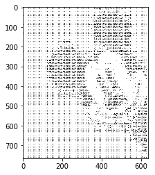

```python
from PIL import Image
import matplotlib.pyplot as plt
%matplotlib inline


# The characrters list which is used to map pixel to char
characters = list("$@B%8&WM#*oahkbdpqwmZO0QLCJUYXzcvunxrjft/\|()1{}[]?-_+~<>i!lI;:,\"^`'. ")


def img2char(img, char_list, width=100, height=50, save=True, out_file=None):
    """
    To convert an image to character painting
    :param img:  Input image
    :param char_list: Corresponding characters
    :param width: The output width
    :param height: The output height
    :param save:  Whether to save to .txt file
    :param out_file: Output file name
    :return:  character painting
    """
    length = len(char_list)
    distance = 256/length  # the distance that a char can cover
    new_img = img.resize((width, height), Image.ANTIALIAS)  # resize to make sure it can be visualize
    painting = ""
    for i in range(height):
        for j in range(width):
            pixel = new_img.getpixel((j, i))
            pixel = pixel[0]*0.2126 + pixel[1]*0.7152 + pixel[2]*0.0722  # convert to grey scale
            painting += char_list[int(pixel/distance)]
        painting += "\n"

    if save:  # save to .txt file
        if out_file is None:
            out_file = 'character_painting'
        with open(out_file+".txt", 'w') as f:
            f.write(painting)

    return painting


# visualize
img = Image.open("test2.jpg")
paint = img2char(img, characters)
print(paint)
plt.imshow(img.resize((500, 600), Image.ANTIALIAS))
plt.show()
paint = Image.open("result.png")
plt.imshow(paint)
plt.show()
```

- After many times of trying, I have found this algorithm works better on simple images. The higher image's contrast is, the better performance it will reach.
- After it output a string, I use a screenshot to keep the result to a .png file. And load it into the notebook, to make it easier for user to compare it with the oringin picture.
- The detailed information can be seen in the code and comment.

### Problem 22

```python
import numpy as np


# -----------Question 1----------------
print("# -----------Question 1----------------")
data = np.random.random((10, 2))  # Randomly generated a 10x2 matrix
x, y = data[:, 0], data[:, 1]  # separate the coordinates
r = np.sqrt(x**2 + y**2).reshape(-1, 1)  # compute r
theta = np.arctan(y/x).reshape(-1, 1)  # compute theta
polar = np.concatenate([r, theta], axis=1)  # gather together

# print the cartesian coordinates and polar coordinates.
print("------cartesian coordinates-------")
print(data)
print("------  polar   coordinates-------")
print(polar)

# -----------Question 2----------------
print("# -----------Question 2----------------")


class Symmetric2DArray(np.ndarray):
    # overwrite a np.ndarray class

    def __setitem__(self, index, value):  # make the array is symmetric
        i, j = index
        super(Symmetric2DArray, self).__setitem__((i, j), value)
        super(Symmetric2DArray, self).__setitem__((j, i), value)


def symmetrize(z):
    """
    convert z to symmetric matrix
    :param z: input 2d array
    :return:  symmetric 2d array
    """
    return np.asarray(z + z.T - np.diag(z.diagonal())).view(Symmetric2DArray)


# an example
S = symmetrize(np.random.randint(0, 10, (4, 4)))
S[1, 3] = 999
print(S)

# -----------Question 3----------------
print("# -----------Question 3----------------")


def get_distance(P0, P1, P):
    P10 = P1 - P0  # Compute verctor P0P1
    P10_mod = (P10 ** 2).sum(axis=1)  # Compute |P0P1|^2
    all_distance = []
    for p in P:
        dot = ((p-P0) * P10).sum(axis=1)  # Compute (p-p0) dot P0P1
        tmp = (dot / P10_mod).reshape(-1, 1)*P10  # Compute tmp vector
        dist = P0-p+tmp  # compute target vector
        all_distance.append(np.sqrt((dist**2).sum(axis=1)))
    return np.array(all_distance)


P0 = np.random.randint(-10, 10, (10, 2))
P1 = np.random.randint(-10, 10,(10, 2))
P = np.random.randint(-10, 10, (10, 2))

print(get_distance(P0, P1, P))
```

```
# -----------Question 1----------------
------cartesian coordinates-------
[[0.3527384  0.06944733]
 [0.67249889 0.82178068]
 [0.52455039 0.44718109]
 [0.95734947 0.69840315]
 [0.48427658 0.29712205]
 [0.6193156  0.49786299]
 [0.41796175 0.57788842]
 [0.47129698 0.89571721]
 [0.05924195 0.13337864]
 [0.99326627 0.3593134 ]]
------  polar   coordinates-------
[[0.35950982 0.19439431]
 [1.06187488 0.88496996]
 [0.68929242 0.70594574]
 [1.1850253  0.63026289]
 [0.56815958 0.55031444]
 [0.79461901 0.67710974]
 [0.71319496 0.94463167]
 [1.01214137 1.08643479]
 [0.14594338 1.15280646]
 [1.05625944 0.34710334]]
# -----------Question 2----------------
[[  8   1  11  15]
 [  1   6   1 999]
 [ 11   1   3   7]
 [ 15 999   7   4]]
# -----------Question 3----------------
[[ 4.94974747  2.94484824  6.68503217  5.78747314  1.31306433 16.09968944
   2.82842712  4.17420651  5.          5.85712236]
 [ 2.12132034  3.58503264  2.4140394   1.2184154   3.15135439  7.60263112
   9.89949494  3.79473319  4.          0.32539569]
 [ 1.41421356  3.96914328  1.67125804  2.4368308   6.95924094 12.07476708
   9.19238816  0.9486833   4.         11.71424472]
 [ 6.36396103  8.45043408  4.27099278  5.27980006  9.71667603  5.81377674
  14.14213562  6.70402864  4.          6.39944851]
 [ 0.70710678  1.02429504  3.8996021   2.84296926  1.57567719 11.18033989
   7.07106781  0.50596443  4.          2.71163072]
 [ 5.65685425  4.60932768 11.51311097 10.25499627  5.90878948 13.41640786
   2.12132034  2.972541   13.          4.66400484]
 [ 9.89949494 11.65135607  6.12794616  7.31049239 11.68627252  1.34164079
  17.67766953 10.8149896   4.          2.60316549]
 [ 0.          1.40840568  4.64238345  3.45217696  0.91914503  9.39148551
   7.77817459  1.83412104  6.          0.86772183]
 [12.02081528 13.18779863  5.57086015  7.00588854 11.29235323  2.68328157
  19.79898987 14.04051281  1.          3.90474824]
 [ 5.65685425  6.91399152  0.          1.31995001  5.64617661  3.57770876
  13.43502884  7.65271194  3.          2.71163072]]
```

- Question 1 is simple, first compute r by pythagorean theorem, and then use np.arctan to compute the angle.
- Question 2 is to overwrite a np.ndarray calss so that make sure the np.ndarray is symmetric.
- Question 3 has using the qualities of properties of triangles, the main thought can be seen from the following picture.

[figure not shown]

### Problem 23

```python
import numpy as np


def bilinear_interp(A, point):
    """
    Bilinear Interpolation Algorithm.
    :param A: Given points
    :param point: Given point which need to compute
    :return: the result of Interpolation
    """
    x, y = point
    x -= 1
    y -= 1
    try:
        return A[x][y]
    except IndexError:
        x1, y1 = int(x), int(y)
        x2, y2 = x1 + 1, y1 + 1
        result = A[x1][y1] * (x2 - x) * (y2 - y) + A[x2][y1] * (x - x1) * (y2 - y) + A[x1][y2] * (x2 - x) * (y - y1) + \
                 A[x2][y2] * (x - x1) * (y - y1)  # based on the formula
        return int(result)


# test
A = np.array([[110, 120, 130], [210, 220, 230], [310, 320, 330]])
print(bilinear_interp(A, (1, 1)))
print(bilinear_interp(A, (2.5, 2.5)))
```

```
110
275
```

- This is a simple algorithm, just apply the fomula and then we can get the output.

### Problem 24

```python
def cartesian_product(sets):
    """
    compute cartesian product of the set
    :param sets: iterable set
    :return: the cartesian product
    """
    tmp_set = [[x] for x in sets[0]]  # initialize a set to store result
    for i in range(1, len(sets)):  # do cartesian product Cumulatively
        result = []
        for tmp in tmp_set:
            for ele in sets[i]:
                result.append(tmp + [ele])
        tmp_set = result
    return tmp_set


# example:
example = [[1, 2, 3], [4, 5], [6, 7]]
print(cartesian_product(example))
```

```
[[1, 4, 6], [1, 4, 7], [1, 5, 6], [1, 5, 7], [2, 4, 6], [2, 4, 7], [2, 5, 6], [2, 5, 7], [3, 4, 6], [3, 4, 7], [3, 5, 6], [3, 5, 7]]
```

- For this problem, we only need to comulatively do cartesian product to the given sets of arrays, and then we can get the answer.

### Problem 25

```python
import numpy as np


def subset(Z, pos, shape, fill=0):
    """
    extract a subset form an array
    :param Z: input array
    :param shape: shape of subset
    :param fill: padding element
    :param pos: subset position
    :return: subset
    """
    result = np.ones(shape)*fill  # initialize a matrix with fill value
    x, y = pos
    x_len, y_len = shape
    rx, ry = x_len//2, y_len//2  # the radius form the center point
    # boarder of subset
    x1 = max(x-rx, 0)
    y1 = max(y-ry, 0)
    x2 = min(x + rx, Z.shape[0])
    y2 = min(y + ry, Z.shape[1])
    # carry the value in Z into the target matrix
    for i in range(x1, x2):
        for j in range(y1, y2):
            result[i+rx-x][j+ry-y] = Z[i][j]
    return result


# example:
Z = np.random.randint(0, 10, (5, 5))
print(Z)
pos = (1, 1)
shape = (4, 4)
fill = 0
print(subset(Z, pos, shape, fill))
```

```
[[6 7 7 7 9]
 [6 4 6 0 8]
 [3 9 7 5 8]
 [5 7 0 7 2]
 [4 7 9 8 7]]
[[0. 0. 0. 0.]
 [0. 6. 7. 7.]
 [0. 6. 4. 6.]
 [0. 3. 9. 7.]]
```

- First initialize a array with given shape and fill value.
- Compute the boarder of the value need to update in the array.
- Compute the relation between the coordinates of two arrays
- Copy the value on the given array to the target array.

### Problem 26

```python
# ----------sub-problem.1----------
def add(A, B):
    """
    add operation of matrix
    :param A:  matrix A
    :param B:  matrix B
    :return:  result
    """
    return [[A[i][j] + B[i][j] for j in range(len(A[i]))] for i in range(len(A))]


# ----------sub-problem.2----------
def subtract(A, B):
    """
    subtract operation of matrix
    :param A:  matrix A
    :param B:  matrix B
    :return:  result
    """
    return [[A[i][j] - B[i][j] for j in range(len(A[i]))] for i in range(len(A))]


# ----------sub-problem.3----------
def scalar_multiply(A, num):
    """
    scalar mulitply operation of matrix
    :param A:  matrix A
    :param num:  number of scalar
    :return:  result
    """
    return [[A[i][j] * num for j in range(len(A[i]))] for i in range(len(A))]


# ----------sub-problem.4----------
def multiply(A, B):
    """
    multiply operation of matrix
    :param A:  matrix A
    :param B:  matrix B
    :return:  result
    """
    result = []
    for i in range(len(A)):
        tmp = []
        for j in range(len(B[0])):
            tmp.append(sum([A[i][k] * B[k][j] for k in range(len(A[0]))]))
        result.append(tmp)
    return result


# ----------sub-problem.5----------
def identity(num):
    """
    create a identity mat
    :param num:  the dim of the mat
    :return:  the identity matrix
    """
    return [[1 if i == j else 0 for j in range(num)] for i in range(num)]


# ----------sub-problem.6----------
def transpose(A):
    """
    transpose a mat
    :param A: input mat
    :return: mat after transposed
    """
    result = []
    for i in range(len(A[0])):
        tmp = []
        for j in range(len(A)):
            tmp.append(A[j][i])
        result.append(tmp)
    return result


# ----------sub-problem.7----------
def get_minor(A, i, j):
    """
    compute the minor of the mat at pos(i,j)
    :param A: input mat
    :param i: pos[0]
    :param j: pos[1]
    :return: minor
    """
    return [row[:j] + row[j+1:] for row in (A[:i]+A[i+1:])]


def get_det(A):
    """
    compute the det of a mat
    :param A: the input mat A
    :return:  the det of A
    """
    # base case for 2x2 matrix
    if len(A) == 2:
        return A[0][0]*A[1][1]-A[0][1]*A[1][0]

    det = 0
    for c in range(len(A)):
        det += ((-1)**c)*A[0][c]*get_det(get_minor(A, 0, c))
    return det


def inverse(A):
    """
    compute the inverse of a mat
    :param A: input mat
    :return: mat after inverse
    """
    det = get_det(A)
    # special case for 2x2 matrix:
    if len(A) == 2:
        return [[A[1][1]/det, -1*A[0][1]/det],
                [-1*A[1][0]/det, A[0][0]/det]]

    # find matrix of cofactors
    result = []
    for r in range(len(A)):
        cofactorsRow = []
        for c in range(len(A)):
            minor = get_minor(A, r, c)
            cofactorsRow.append(((-1)**(r+c)) * get_det(minor))
        result.append(cofactorsRow)
    result = transpose(result)
    for r in range(len(result)):
        for c in range(len(result)):
            result[r][c] = result[r][c]/det
    return result


# ---------Test examples-----------
matrix_a = [[12, 10], [3, 9]]
matrix_b = [[3, 4], [7, 4]]
matrix_c = [[11, 12, 13, 14], [21, 22, 23, 24], [31, 32, 33, 34], [41, 42, 43, 44]]
matrix_d = [[3, 0, 2], [2, 0, -2], [0, 1, 1]]

print("------------add----------")
print(add(matrix_a, matrix_b))
print("-------subtract----------")
print(subtract(matrix_a, matrix_b))
print("-----scalar_multiply-----")
print(scalar_multiply(matrix_b, 3))
print("---------multiply--------")
print(multiply(matrix_a, matrix_b))
print("--------identity---------")
print(identity(3))
print("---------transpose-------")
print(transpose(matrix_c))
print("---------inverse---------")
print(inverse(matrix_d))
```

```
------------add----------
[[15, 14], [10, 13]]
-------subtract----------
[[9, 6], [-4, 5]]
-----scalar_multiply-----
[[9, 12], [21, 12]]
---------multiply--------
[[106, 88], [72, 48]]
--------identity---------
[[1, 0, 0], [0, 1, 0], [0, 0, 1]]
---------transpose-------
[[11, 21, 31, 41], [12, 22, 32, 42], [13, 23, 33, 43], [14, 24, 34, 44]]
---------inverse---------
[[0.2, 0.2, 0.0], [-0.2, 0.3, 1.0], [0.2, -0.3, 0.0]]
```

- **add:** use list parsing can easily solve this problem.
- **subtract:** use list parsing can easily solve this problem.
- **scalar_multiply:** use list parsing can easily solve this problem.
- **multiply:** use two-level nested loop and list parsing can solve this problem.
- **identity:** use list parsing can easily solve this problem.
- **transpose:** use two-level nested loop to transfer the value to new position
- **inverse:** this is complex and based on the fact that:
  1. $A^{-1} = det(A)^{-1}adj(A)$ where det(A) is the determinant of matrix and adj(A) is the adjugate matrix of A. See Adjugate_matrix for more details.
  2. $det(A) = \sum_i^n a_{ij}(-1)^{i+j}M_{ij}$ where $M_{ij}$ is the minor of matrix $A$ at $(i, j)$ The cofactors feature prominently in Laplace's formula for the expansion of determinants, which is a method of computing larger determinants in terms of smaller ones. See Minor) for more details.

### Problem 27

```python
def GCD(x, y):
    """
    find the greatest common divisor using Euclidean Algorithm
    :param x: num
    :param y: num
    :return: the gcd
    """
    tmp = x % y
    while tmp != 0:
        x = y
        y = tmp
        tmp = x % y
    return y


# ----------Examples----------
print("GCD(3, 5):", GCD(3, 5))
print("GCD(6, 3):", GCD(6, 3))
print("GCD(-2, 6):", GCD(-2, 6))
print("GCD(0, 3):", GCD(0, 3))
```

```
GCD(3, 5): 1
GCD(6, 3): 3
GCD(-2, 6): 2
GCD(0, 3): 3
```

- Using Euclidean Algorithm to solve this problem, see [Euclidean Algorithm](https://baike.baidu.com/item/欧几里得算法/1647675?fromtitle=%E8%BE%97%E8%BD%AC%E7%9B%B8%E9%99%A4%E6%B3%95&fromid=4625352#1) for more details.

### Problem28

```python
def consecutive_seq(N):
    """
    Find all consecutive positive number sequences whose sum is N
    :param N: input num
    :return: all sequence
    """
    if N == 0 or N == 1:  # special case
        return []
    result = []
    i = 1
    tmp = [i]
    while i <= N//2+1 and i+1 != N:  # terminal condition
        i += 1
        tmp = tmp + [i]
        cur_sum = sum(tmp)
        while cur_sum > N:
            tmp = tmp[1:]
            cur_sum = sum(tmp)
        if cur_sum == N:
            result.append(tmp.copy())
    return result


# ----------Example----------
result = consecutive_seq(2)
for ele in result:
    print(ele)
```

[output not shown]

- The main steps of the algorithm:
  1. The iteration i can reach N//2+1 at most, for any (N//2+1 + N//2+2)>N
  2. Maintain a list to record current list.
  3. If
     1. sum(current list) + i == N , add the list+[i] to the result
     2. sum(current list) + i < N, add i to the list and keep iteration
     3. sum(current list) + i > N, remove first item of list until sum(current list) + i <= N
  4. Return the final result.

### Problem 29

```python
import re


def password_checking(s):
    """
    to check whether a sequence of input strings are qualified
    :param s: input sequence of strings
    :return: sequence of valid string
    """
    result = []

    strings = s.split(",")
    for password in strings:
        # at least a letter between [a-z]
        if not re.search("[a-z]", password):
            continue
        # At least 1 number between [0-9]
        if not re.search("[0-9]", password):
            continue
        # At least 1 letter between [A-Z]
        if not re.search("[A-Z]", password):
            continue
        # At least 1 character from [$#@]
        if not re.search("[$#@]", password):
            continue
        # Minimum length of transaction password: 6
        if len(password) < 6:
            continue
        if len(password) > 12:
            continue
        result.append(password)

    return ",".join(result)


# ---------Examples---------
passwords = "ABd1234@1,a F1#,2w3E*,2We3345"
print(password_checking(passwords))
```

```
ABd1234@1
```

- The program of password checking is simple with the help to *re* toolkit.
- You can check the code for the details.

**So far, the first lab has finally be completed!! Thanks for the efforts of inspection of this homework!!**